# Power analysis by simulation

power analysis

Author

maj

Published

March 13, 2025

Modified

March 13, 2025

```r
library(data.table)
library(ggplot2)
library(gt)
```

Power analyses inform us as to chances an experiment has of identifying a treatment differences based on our criteria, various assumptions about the design, sample size and over the effect sizes we imagine might arise. Power analyses can be implemented via simulation. The following methods provide a basic demonstration of the power analysis for an experiment with a single analysis where we consider the binary outcome under differing treatment regimes at a fixed sample and a range of effect sizes. For the sake of the example, logistic regression is used as the analysis model although one might reasonable select from a range of analysis models, with some being more efficient than others. For example, non-parametric approaches may yield lower power, but might make less assumptions, depending on the particular method chosen.

Method 1 creates a fine grid over the entire effect size range of interest and then performs a single trial for each of these effect sizes based on data simulated at this effect size. For each trial, we will either detect an effect or not based on the criteria we are using to make a decision (i.e. reject a null hypothesis). The probability of detecting an effect for each simulated trial equates to the power at that effect size. If we interpolate over these indicator values as to whether an effect was detected or not, we can produce an approximation of the power curve over the entire range.

```r
n_sim <- 10000
p_0 <- 0.5
rd <- seq(-0.25, 0.25, len = n_sim)
win <- numeric(n_sim)

y_0 <- rbinom(n_sim, 100, p_0)
y_1 <- rbinom(n_sim, 100, p_0 + rd)

i <- 1
for(i in 1:n_sim){

  y <- rbind(
    c(y_0[i], 100 - y_0[i]),
    c(y_1[i], 100 - y_1[i])
  )
  x <- c(0, 1)

  f1 <- glm(y ~ x, family = binomial)
  # assume a typical frequentist critria
  win[i] <- summary(f1)$coef[2, 4] < 0.025

}


d_fig_1 <- data.table(
  x = rd,
  win = win
)
```

Method 2 simulates a large number of trials at each effect size of interest. The power at each effect size is computed as the proportion of trials where the effect was identified based on the criteria we are using to make a decision. This process is done for a range of effect sizes below. Method 2 is clearly more computationally demanding than method 1.

```r
n_sim <- 5000
p_0 <- 0.5
p_1 <- p_0 + c(-0.2, -0.1, 0.0, 0.1, 0.2)

pwr <- numeric(length(p_1))


for(i in 1:length(p_1)){

  y_0 <- rbinom(n_sim, 100, p_0)
  y_1 <- rbinom(n_sim, 100, p_1[i])

  win <- numeric(n_sim)

  for(j in 1:n_sim){

    y <- rbind(
      c(y_0[j], 100 - y_0[j]),
      c(y_1[j], 100 - y_1[j])
    )
    x <- c(0, 1)

    f1 <- glm(y ~ x, family = binomial)
    win[j] <- summary(f1)$coef[2, 4] < 0.025

  }

  pwr[i] <- mean(win)
}


d_fig_2 <- data.table(
  x = p_1 - p_0,
  pwr = pwr
)
```

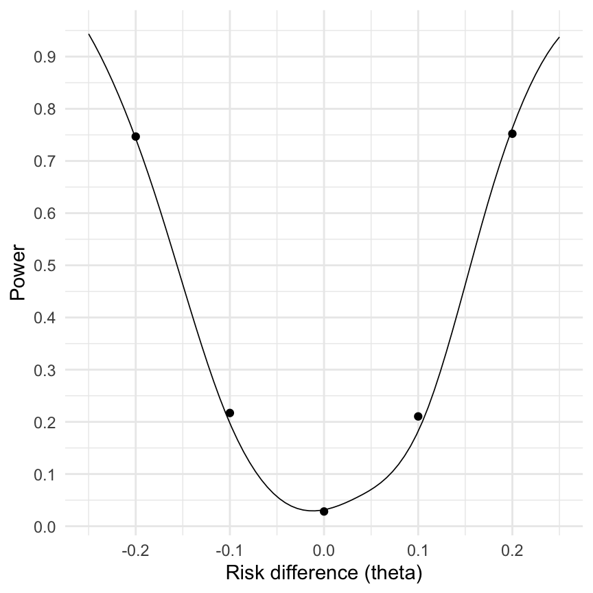

Figure 1: Power curves characterising power by effect size at a sample size of 100 per arm in two group study with binary outcome (points show results from method 2)